# Day 10

```python
%matplotlib inline
import pandas as pd
import numpy as np
```

```python
titles = pd.read_csv('titles.csv')
```

```python
titles.head()
```

|  | title | year |
| --- | --- | --- |
| 0 | Tasveer Mere Sanam | 1996 |
| 1 | Only You | 1994 |
| 2 | El pueblo del terror | 1970 |
| 3 | Machine | 2007 |
| 4 | MARy | 2008 |

# 1.How many movies are listed in the titles dataframe?

```python
num_movies = titles.shape[0]
print("Number of movies listed:", num_movies)
```

```
Number of movies listed: 244914
```

# 2.What are the earliest two films listed in the titles dataframe?

```python
earliest_two_films=titles.sort_values(by = 'year').head(2)
print(earliest_two_films)
```

```
                     title  year
193222          Miss Jerry  1894
51388   The Startled Lover  1898
```

# 3.How many movies have the title "Hamlet"?

```python
hamlet_movies = titles[titles['title'] == 'Hamlet']
num_hamlet_movies = hamlet_movies.shape[0]
print("Number of movies with the title 'Hamlet':", num_hamlet_movies)
```

```
Number of movies with the title 'Hamlet': 20
```

# 4.How many movies are titled "North by Northwest"?

```python
north_by_northwest_movies = titles[titles['title'] == 'North by Northwest']
num_north_by_northwest_movies = north_by_northwest_movies.shape[0]
print("Number of movies titled 'North by Northwest':", num_north_by_northwest_movies)
```

```
Number of movies titled 'North by Northwest': 1
```

# 5.When was the first movie titled "Hamlet" made?

```python
hamlet_movies = titles[titles['title'] == 'Hamlet']
earliest_hamlet_movie = hamlet_movies.sort_values(by='year').iloc[0]
print("The first movie titled 'Hamlet' was made in:", earliest_hamlet_movie['year'])
```

```
The first movie titled 'Hamlet' was made in: 1910
```

# 6.List all of the "Treasure Island" movies from earliest to most recent.

```python
treasure_island_movies = titles[titles['title'] == 'Treasure Island']
sorted_treasure_island_movies = treasure_island_movies.sort_values(by='year')
print(sorted_treasure_island_movies)
```

```
                  title  year
55686   Treasure Island  1918
196514  Treasure Island  1920
141822  Treasure Island  1934
77354   Treasure Island  1950
65051   Treasure Island  1972
37238   Treasure Island  1973
173051  Treasure Island  1985
27076   Treasure Island  1999
```

# 7.How many movies were made in the year 1950?

```python
movies_1950 = titles[titles['year'] == 1950]
num_movies_1950 = movies_1950.shape[0]
print("Number of movies made in the year 1950:", num_movies_1950)
```

```
Number of movies made in the year 1950: 1113
```

# 8.How many movies were made in the year 1960?

```python
movies_1960 = titles[titles['year'] == 1960]
num_movies_1960 = movies_1960.shape[0]
print("Number of movies made in the year 1960:", num_movies_1960)
```

```
Number of movies made in the year 1960: 1549
```

# 9.How many movies were made from year 1950 through 1959?

```python
movies_1950s = titles[(titles['year'] >= 1950) & (titles['year'] <= 1959)]
num_movies_1950s = movies_1950s.shape[0]
print("Number of movies made from 1950 through 1959:", num_movies_1950s)
```

```
Number of movies made from 1950 through 1959: 12934
```

# 10.in what years has a movie titled "Batman" been released?

```python
movies_year=titles[titles['title']=='Batman']
movie_title=movies_year['year'].unique()
print("years has a movie titled 'Batman':",movie_title)
```

```
years has a movie titled 'Batman': [1943 1989]
```

# 11.How many roles were there in the movie "Inception"?

```python
import pandas as pd
```

```python
cast = pd.read_csv('cast.csv')
```

```python
inception_roles = cast[cast['title'] == 'Inception']

num_roles_inception = inception_roles.shape[0]

print("Number of roles in the movie 'Inception':", num_roles_inception)
```

```
Number of roles in the movie 'Inception': 78
```

# 12.How many roles in the movie "Inception" are NOT ranked by an "n" value?

```python
inception_cast = cast[cast['title'] == 'Inception']
num_roles_inception = inception_cast['title'].nunique()

print("without_n_values:",num_roles_inception)
```

[output not shown]

# 13.But how many roles in the movie "Inception" did receive an "n" value?

```python
inception_roles_with_rank = cast[(cast['title'] == 'Inception') & cast['n'].notna()]
num_roles_with_rank = inception_roles_with_rank.shape[0]

print("Number of roles in the movie 'Inception' with a rank (n) value:", num_roles_with_rank)
```

```
Number of roles in the movie 'Inception' with a rank (n) value: 51
```

# 14.Display the cast of "North by Northwest" in their correct "n"-value order, ignoring roles that did not earn a numeric "n" value.

```python
north_by_northwest_cast = cast[(cast['title'] == 'North by Northwest') & cast['n'].notna()]
sorted_cast = north_by_northwest_cast.sort_values(by='n')

print(sorted_cast[['n', 'name']])
```

```
            n                  name
871426    1.0            Cary Grant
3518333   2.0       Eva Marie Saint
1457165   3.0           James Mason
3157232   4.0   Jessie Royce Landis
356707    5.0        Leo G. Carroll
3048272   6.0  Josephine Hutchinson
1695173   7.0           Philip Ober
1275337   8.0         Martin Landau
2447081   9.0         Adam Williams
1811387  10.0          Edward Platt
665768   11.0     Robert Ellenstein
2295714  12.0          Les Tremayne
464736   13.0       Philip Coolidge
1508344  14.0         Patrick McVey
206471   15.0          Edward Binns
1384780  16.0             Ken Lynch
```

# 15.Display the entire cast, in "n"-order, of the 1972 film "Sleuth".

```python
sleuth_1972_cast = cast[(cast['title'] == 'Sleuth') & (cast['year'] == 1972)]
sorted_cast = sleuth_1972_cast.sort_values(by='n')

print(sorted_cast[['n', 'name']])
```

```
           n                name
1705394  1.0    Laurence Olivier
326773   2.0       Michael Caine
373876   3.0      Alec Cawthorne
1465483  4.0  John (II) Matthews
2724553  5.0  Eve (III) Channing
1448690  6.0        Teddy Martin
```

# 16.Now display the entire cast, in "n"-order, of the 2007 version of "Sleuth".

```python
sleuth_2007_cast = cast[(cast['title'] == 'Sleuth') & (cast['year'] == 2007)]
sorted_cast = sleuth_2007_cast.sort_values(by='n')

print(sorted_cast[['n', 'name']])
```

```
           n                 name
326774   1.0        Michael Caine
1293634  2.0             Jude Law
1805907  3.0        Harold Pinter
260242   NaN      Kenneth Branagh
373877   NaN  Alec (II) Cawthorne
2724552  NaN    Eve (II) Channing
3370424  NaN    Carmel O'Sullivan
```

# 17.How many roles were credited in the silent 1921 version of Hamlet?

```python
hamlet_1921_cast = cast[(cast['title'] == 'Hamlet') & (cast['year'] == 1921)]
num_credited_roles = hamlet_1921_cast.shape[0]

print("Number of roles credited in the silent 1921 version of 'Hamlet':", num_credited_roles)
```

```
Number of roles credited in the silent 1921 version of 'Hamlet': 9
```

# 18.How many roles were credited in Branagh's 1996 Hamlet?

```python
branagh_hamlet_cast = cast[(cast['title'] == 'Hamlet') & (cast['year'] == 1996)]
num_credited_roles = branagh_hamlet_cast.shape[0]

print("Number of roles credited in Branagh's 1996 version of 'Hamlet':", num_credited_roles)
```

```
Number of roles credited in Branagh's 1996 version of 'Hamlet': 54
```

# 19.How many "Hamlet" roles have been listed in all film credits through history?

```python
hamlet_roles = cast[cast['title'] == 'Hamlet']
num_hamlet_roles = hamlet_roles.shape[0]

print("Number of 'Hamlet' roles listed in all film credits throughout history:", num_hamlet_roles)
```

```
Number of 'Hamlet' roles listed in all film credits throughout history: 342
```

# 20.How many people have played an "Ophella"?

```python
ophelia_actors = cast[cast['character'] == 'Ophelia']
num_ophelia_actors = ophelia_actors['name'].nunique()

print("Number of people who have played the character 'Ophelia':", num_ophelia_actors)
```

```
Number of people who have played the character 'Ophelia': 115
```

# 21.How many people have played a role called "The Dude"?

```python
the_dude_actors = cast[cast['character'] == 'The Dude']
num_the_dude_actors = the_dude_actors['name'].nunique()

print("Number of people who have played a role called 'The Dude':", num_the_dude_actors)
```

```
Number of people who have played a role called 'The Dude': 19
```

# 22.How many people have played a role called "The Stranger"?

```python
the_stranger_actors = cast[cast['character'] == 'The Stranger']
num_the_stranger_actors = the_stranger_actors['name'].nunique()

print("Number of people who have played a role called 'The Stranger':", num_the_stranger_actors)
```

```
Number of people who have played a role called 'The Stranger': 202
```

# 23.How many roles has Sidney Poitier played throughout his career?

```python
sidney_poitier_roles = cast[cast['name'] == 'Sidney Poitier']
num_sidney_poitier_roles = sidney_poitier_roles['character'].nunique()

print("Number of roles played by Sidney Poitier throughout his career:", num_sidney_poitier_roles)
```

```
Number of roles played by Sidney Poitier throughout his career: 41
```

# 24.How many roles has Judi Dench played?

```python
judi_dench_roles = cast[cast['name'] == 'Judi Dench']
num_judi_dench_roles = judi_dench_roles['character'].nunique()

print("Number of roles played by Judi Dench throughout her career:", num_judi_dench_roles)
```

```
Number of roles played by Judi Dench throughout her career: 46
```

# 25.List the supporting roles (having n=2) played by Cary Grant in the 1940s, in order by year.

```python
cary_grant_supporting_roles_1940s = cast[(cast['name'] == 'Cary Grant') & (cast['n'] == 2) & (cast['year'] >= 1940) & (cast['year'] <= 1949)]
sorted_roles = cary_grant_supporting_roles_1940s.sort_values(by='year')

print(sorted_roles[['year', 'character']])
```

```
        year    character
871423  1940   Nick Arden
871433  1941  Roger Adams
```

# 26.List the leading roles that Cary Grant played in the 1940s in order by year.

```python
cary_grant_leading_roles_1940s = cast[(cast['name'] == 'Cary Grant') & (cast['n'] == 1) & (cast['year'] >= 1940) & (cast['year'] <= 1949)]
sorted_roles = cary_grant_leading_roles_1940s.sort_values(by='year')

print(sorted_roles[['year', 'character']])
```

```
        year                             character
871448  1940                           Matt Howard
871407  1940                          Walter Burns
871450  1940                    C. K. Dexter Haven
871438  1941                      Johnnie Aysgarth
871452  1942                          Leopold Dilg
871429  1942                 Patrick 'Pat' O'Toole
871398  1943                         Capt. Cassidy
871422  1943  Joe Adams -posing as Joe Bascopolous
871430  1944                           Jerry Flynn
871390  1944                     Mortimer Brewster
871425  1944                            Ernie Mott
871424  1946                           Cole Porter
871427  1946                                Devlin
871444  1947                           Dick Nugent
871445  1947                                Dudley
871421  1948                         Jim Blandings
871402  1948                     Dr. Madison Brown
871411  1949                 Captain Henri Rochard
```

# 27.How many roles were available for actors in the 1950s?

```python
roles_in_1950s = cast[(cast['year'] >= 1950) & (cast['year'] <= 1959)]
num_roles_in_1950s = roles_in_1950s.shape[0]

print("Number of roles available for actors in the 1950s:", num_roles_in_1950s)
```

```
Number of roles available for actors in the 1950s: 215471
```

# 28.How many roles were available for actresses in the 1950s?

```python
actress_roles_in_1950s = cast[(cast['year'] >= 1950) & (cast['year'] <= 1959) & (cast['type'] == 'actress')]
num_actress_roles_in_1950s = actress_roles_in_1950s.shape[0]

print("Number of roles available for actresses in the 1950s:", num_actress_roles_in_1950s)
```

```
Number of roles available for actresses in the 1950s: 57733
```

# 29.How many leading roles (n=1) were available from the beginning of film history through 1980?

```python
leading_roles_through_1980 = cast[(cast['n'] == 1) & (cast['year'] <= 1980)]
num_leading_roles_through_1980 = leading_roles_through_1980.shape[0]

print("Number of leading roles (n=1) available from the beginning of film history through 1980:", num_leading_roles_through_1980)
```

```
Number of leading roles (n=1) available from the beginning of film history through 1980: 65140
```

# 30.How many non-leading roles were available through from the beginning of film history through 1980?

```python
non_leading_roles_through_1980 = cast[(cast['n'] != 1) & (cast['year'] <= 1980)]
num_non_leading_roles_through_1980 = non_leading_roles_through_1980.shape[0]

print("Number of non-leading roles (n not equal to 1) available from the beginning of film history through 1980:", num_non_leading_roles_through_1980)
```

```
Number of non-leading roles (n not equal to 1) available from the beginning of film history through 1980: 1117667
```

# 31.How many roles through 1980 were minor enough that they did not warrant a numeric "n" rank?

```python
roles_without_n_rank_through_1980 = cast[(cast['year'] <= 1980) & (cast['n'].isna() | (cast['n'] != 1))]
num_roles_without_n_rank_through_1980 = roles_without_n_rank_through_1980.shape[0]

print("Number of roles through 1980 without a numeric 'n' rank:", num_roles_without_n_rank_through_1980)
```

```
Number of roles through 1980 without a numeric 'n' rank: 1117667
```

# Excersies 2

```python
titles.head()
```

|  | title | year |
| --- | --- | --- |
| 0 | Tasveer Mere Sanam | 1996 |
| 1 | Only You | 1994 |
| 2 | El pueblo del terror | 1970 |
| 3 | Machine | 2007 |
| 4 | MARy | 2008 |

```python
cast.head()
```

|  | title | year | name | type | character | n |
| --- | --- | --- | --- | --- | --- | --- |
| 0 | Closet Monster | 2015 | Buffy #1 | actor | Buffy 4 | 31.0 |
| 1 | Suuri illusioni | 1985 | Homo $ | actor | Guests | 22.0 |
| 2 | Battle of the Sexes | 2017 | $hutter | actor | Bobby Riggs Fan | 10.0 |
| 3 | Secret in Their Eyes | 2015 | $hutter | actor | 2002 Dodger Fan | NaN |
| 4 | Steve Jobs | 2015 | $hutter | actor | 1988 Opera House Patron | NaN |

# 1.What are the ten most common movie names of all time?

```python
movie_name_counts = titles['title'].value_counts()
top_ten_movie_names = movie_name_counts.head(10)

print("Top ten most common movie names of all time:")
print(top_ten_movie_names)
```

```
Top ten most common movie names of all time:
Hamlet                  20
Carmen                  17
Macbeth                 16
The Outsider            12
Maya                    12
Temptation              12
Freedom                 11
Honeymoon               11
Othello                 11
The Three Musketeers    11
Name: title, dtype: int64
```

# 2.Which three years of the 1930s saw the most films released?

```python
movies_in_1930s = titles[(titles['year'] >= 1930) & (titles['year'] <= 1939)]
movie_counts_by_year = movies_in_1930s['year'].value_counts()

top_three_years = movie_counts_by_year.head(3)

print("Top three years of the 1930s with the most films released:")
print(top_three_years)
```

```
Top three years of the 1930s with the most films released:
1937    1224
1936    1169
1938    1163
Name: year, dtype: int64
```

# 3.Plot the number of films that have been released each decade over the history of cinema.

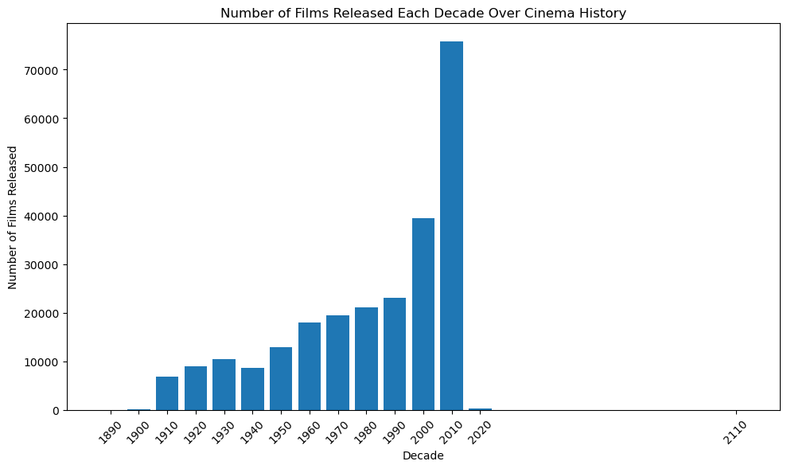

```python
import pandas as pd
import matplotlib.pyplot as plt
titles['decade'] = (titles['year'] // 10) * 10

decade_counts = titles['decade'].value_counts().sort_index()

plt.figure(figsize=(10, 6))
plt.bar(decade_counts.index, decade_counts.values, width=8, align='center')
plt.xlabel('Decade')
plt.ylabel('Number of Films Released')
plt.title('Number of Films Released Each Decade Over Cinema History')
plt.xticks(decade_counts.index, rotation=45)
plt.tight_layout()

plt.show()
```

# 4.Plot the number of "Hamlet" films made each decade.

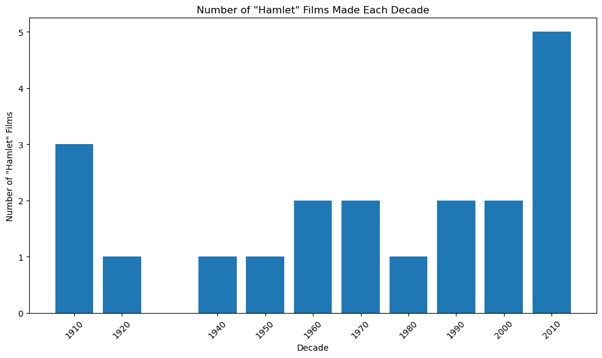

```python
hamlet_movies = titles[titles['title'] == 'Hamlet']

hamlet_movies['decade'] = (hamlet_movies['year'] // 10) * 10

hamlet_decade_counts = hamlet_movies['decade'].value_counts().sort_index()

plt.figure(figsize=(10, 6))
plt.bar(hamlet_decade_counts.index, hamlet_decade_counts.values, width=8, align='center')
plt.xlabel('Decade')
plt.ylabel('Number of "Hamlet" Films')
plt.title('Number of "Hamlet" Films Made Each Decade')
plt.xticks(hamlet_decade_counts.index, rotation=45)
plt.tight_layout()

plt.show()
```

# 5.Plot the number of "Rustler" characters in each decade of the history of film.

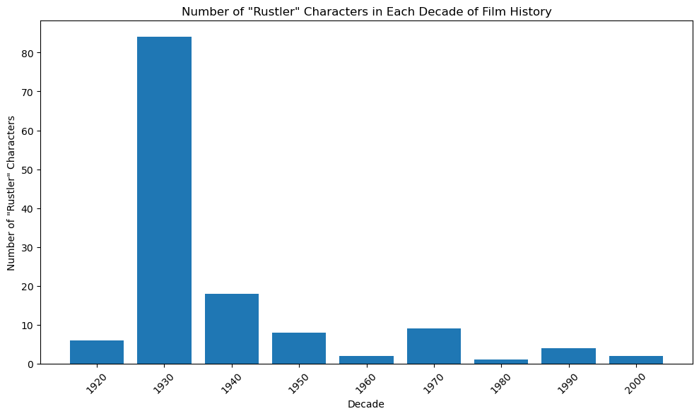

```python
rustler_characters = cast[cast['character'] == 'Rustler']

rustler_characters['decade'] = (rustler_characters['year'] // 10) * 10

rustler_decade_counts = rustler_characters['decade'].value_counts().sort_index()

plt.figure(figsize=(10, 6))
plt.bar(rustler_decade_counts.index, rustler_decade_counts.values, width=8, align='center')
plt.xlabel('Decade')
plt.ylabel('Number of "Rustler" Characters')
plt.title('Number of "Rustler" Characters in Each Decade of Film History')
plt.xticks(rustler_decade_counts.index, rotation=45)
plt.tight_layout()

plt.show()
```

# 6.Plot the number of "Hamlet" characters each decade.

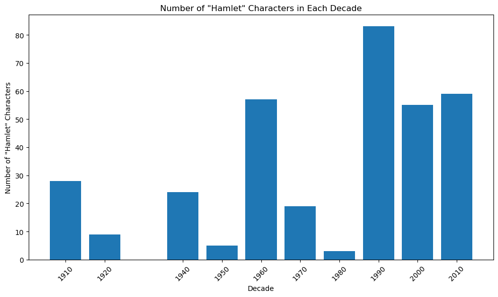

```python
hamlet_characters = cast[(cast['title'] == 'Hamlet')]

hamlet_characters['decade'] = (hamlet_characters['year'] // 10) * 10

hamlet_decade_counts = hamlet_characters['decade'].value_counts().sort_index()

plt.figure(figsize=(10, 6))
plt.bar(hamlet_decade_counts.index, hamlet_decade_counts.values, width=8, align='center')
plt.xlabel('Decade')
plt.ylabel('Number of "Hamlet" Characters')
plt.title('Number of "Hamlet" Characters in Each Decade')
plt.xticks(hamlet_decade_counts.index, rotation=45)
plt.tight_layout()

plt.show()
```

# 7.What are the 11 most common character names in movie history?

```python
character_name_counts = cast['character'].value_counts()
top_11_character_names = character_name_counts.head(11)

print("Top 11 most common character names in movie history:")
print(top_11_character_names)
```

```
Top 11 most common character names in movie history:
Himself        20746
Dancer         12477
Extra          11948
Reporter        8434
Student         7773
Doctor          7669
Party Guest     7245
Policeman       7029
Nurse           6999
Bartender       6802
Herself         6705
Name: character, dtype: int64
```